# TIA R Course Project: Titanic RF Model with Basic Feature Engineering

Brian Choi

June 16, 2019

This is my capstone project for The Infinite Actuary R course. I had some R experience from my work, but did not have chance to use machine learning libraries. The course exposed me to common data cleaning techniques, visualizations, and couple of basic ML libraries which I will be utilizing below. Since I decided to focus on Python over R, I will be revisiting this competition with Python and do more in-depth analysis in the coming weeks!

Please check out my **LinkedIn article on the road map for learning DS with Python as an actuary** [(link)](https://www.linkedin.com/pulse/learning-data-science-actuary-resources-reviews-my-brian), especially if you are also working in actuarial field/insurance industry!

**About the model:**

In this R markdown model, I do basic level of **feature engineering** on missing Ages using title extracted from the name variable. Based on what we know about the incident (probably from the movie!), sex and age were two important factors in survival. Women and children were prioritized for lifeboats. It made sense to me that addressing missing age variable would increase performance of any models. I chose **Random Forest** model for this classification problem.

# 1 Load Libraries and Read in Input Data

```r
library(randomForest)
```

```r
library(ggplot2)
library(stringr)
set.seed(917)

ti_train <- read.csv("TIA_Proj5/train.csv", na.strings=c("")) #for local machine
ti_test  <- read.csv("TIA_Proj5/test.csv", na.strings=c("")) #for local machine

#ti_train <- read.csv("../input/train.csv", na.strings=c("")) #for Kaggle kernel
#ti_test  <- read.csv("../input/test.csv", na.strings=c("")) #for Kaggle kernel
```

## 1.1 Examine Variable Types and Look for Missing Values

```r
head(ti_train)
```

```
##   PassengerId Survived Pclass
## 1           1        0      3
## 2           2        1      1
## 3           3        1      3
## 4           4        1      1
## 5           5        0      3
## 6           6        0      3
##                                                  Name    Sex Age SibSp
## 1                             Braund, Mr. Owen Harris   male  22     1
## 2 Cumings, Mrs. John Bradley (Florence Briggs Thayer) female  38     1
## 3                              Heikkinen, Miss. Laina female  26     0
## 4        Futrelle, Mrs. Jacques Heath (Lily May Peel) female  35     1
## 5                            Allen, Mr. William Henry   male  35     0
## 6                                    Moran, Mr. James   male  NA     0
##   Parch           Ticket    Fare Cabin Embarked
## 1     0        A/5 21171  7.2500  <NA>        S
## 2     0         PC 17599 71.2833   C85        C
## 3     0 STON/O2. 3101282  7.9250  <NA>        S
## 4     0           113803 53.1000  C123        S
## 5     0           373450  8.0500  <NA>        S
## 6     0           330877  8.4583  <NA>        Q
```

```r
summary(ti_train)
```

```
##   PassengerId       Survived          Pclass
##  Min.   :  1.0   Min.   :0.0000   Min.   :1.000
##  1st Qu.:223.5   1st Qu.:0.0000   1st Qu.:2.000
##  Median :446.0   Median :0.0000   Median :3.000
##  Mean   :446.0   Mean   :0.3838   Mean   :2.309
##  3rd Qu.:668.5   3rd Qu.:1.0000   3rd Qu.:3.000
##  Max.   :891.0   Max.   :1.0000   Max.   :3.000
##
##                                     Name         Sex           Age
##  Abbing, Mr. Anthony                  :  1   female:314   Min.   : 0.42
##  Abbott, Mr. Rossmore Edward          :  1   male  :577   1st Qu.:20.12
##  Abbott, Mrs. Stanton (Rosa Hunt)     :  1                Median :28.00
##  Abelson, Mr. Samuel                  :  1                Mean   :29.70
##  Abelson, Mrs. Samuel (Hannah Wizosky):  1                3rd Qu.:38.00
##  Adahl, Mr. Mauritz Nils Martin       :  1                Max.   :80.00
##  (Other)                              :885                NA's   :177
##      SibSp           Parch             Ticket         Fare
##  Min.   :0.000   Min.   :0.0000   1601    :  7   Min.   :  0.00
##  1st Qu.:0.000   1st Qu.:0.0000   347082  :  7   1st Qu.:  7.91
##  Median :0.000   Median :0.0000   CA. 2343:  7   Median : 14.45
##  Mean   :0.523   Mean   :0.3816   3101295 :  6   Mean   : 32.20
##  3rd Qu.:1.000   3rd Qu.:0.0000   347088  :  6   3rd Qu.: 31.00
##  Max.   :8.000   Max.   :6.0000   CA 2144 :  6   Max.   :512.33
##                                   (Other) :852
##          Cabin     Embarked
##  B96 B98    :  4   C   :168
##  C23 C25 C27:  4   Q   : 77
##  G6         :  4   S   :644
##  C22 C26    :  3   NA's:  2
##  D          :  3
##  (Other)    :186
##  NA's       :687
```

```r
str(ti_train)
```

```
## 'data.frame':    891 obs. of  12 variables:
##  $ PassengerId: int  1 2 3 4 5 6 7 8 9 10 ...
##  $ Survived   : int  0 1 1 1 0 0 0 0 1 1 ...
##  $ Pclass     : int  3 1 3 1 3 3 1 3 3 2 ...
##  $ Name       : Factor w/ 891 levels "Abbing, Mr. Anthony",..: 109 191 358 277 16 559 520 629 417 581 ...
##  $ Sex        : Factor w/ 2 levels "female","male": 2 1 1 1 2 2 2 2 1 1 ...
##  $ Age        : num  22 38 26 35 35 NA 54 2 27 14 ...
##  $ SibSp      : int  1 1 0 1 0 0 0 3 0 1 ...
##  $ Parch      : int  0 0 0 0 0 0 0 1 2 0 ...
##  $ Ticket     : Factor w/ 681 levels "110152","110413",..: 524 597 670 50 473 276 86 396 345 133 ...
##  $ Fare       : num  7.25 71.28 7.92 53.1 8.05 ...
##  $ Cabin      : Factor w/ 147 levels "A10","A14","A16",..: NA 82 NA 56 NA NA 130 NA NA NA ...
##  $ Embarked   : Factor w/ 3 levels "C","Q","S": 3 1 3 3 3 2 3 3 3 1 ...
```

Class, Survived, PassengerID should be factors.  
Cabin is mostly NA. Cabin and Ticket won’t be good predictors.

```r
head(ti_test)
```

```
##   PassengerId Pclass                                         Name    Sex
## 1         892      3                             Kelly, Mr. James   male
## 2         893      3             Wilkes, Mrs. James (Ellen Needs) female
## 3         894      2                    Myles, Mr. Thomas Francis   male
## 4         895      3                             Wirz, Mr. Albert   male
## 5         896      3 Hirvonen, Mrs. Alexander (Helga E Lindqvist) female
## 6         897      3                   Svensson, Mr. Johan Cervin   male
##    Age SibSp Parch  Ticket    Fare Cabin Embarked
## 1 34.5     0     0  330911  7.8292  <NA>        Q
## 2 47.0     1     0  363272  7.0000  <NA>        S
## 3 62.0     0     0  240276  9.6875  <NA>        Q
## 4 27.0     0     0  315154  8.6625  <NA>        S
## 5 22.0     1     1 3101298 12.2875  <NA>        S
## 6 14.0     0     0    7538  9.2250  <NA>        S
```

```r
summary(ti_test)
```

```
##   PassengerId         Pclass
##  Min.   : 892.0   Min.   :1.000
##  1st Qu.: 996.2   1st Qu.:1.000
##  Median :1100.5   Median :3.000
##  Mean   :1100.5   Mean   :2.266
##  3rd Qu.:1204.8   3rd Qu.:3.000
##  Max.   :1309.0   Max.   :3.000
##
##                                         Name         Sex
##  Abbott, Master. Eugene Joseph            :  1   female:152
##  Abelseth, Miss. Karen Marie              :  1   male  :266
##  Abelseth, Mr. Olaus Jorgensen            :  1
##  Abrahamsson, Mr. Abraham August Johannes :  1
##  Abrahim, Mrs. Joseph (Sophie Halaut Easu):  1
##  Aks, Master. Philip Frank                :  1
##  (Other)                                  :412
##       Age            SibSp            Parch             Ticket
##  Min.   : 0.17   Min.   :0.0000   Min.   :0.0000   PC 17608:  5
##  1st Qu.:21.00   1st Qu.:0.0000   1st Qu.:0.0000   113503  :  4
##  Median :27.00   Median :0.0000   Median :0.0000   CA. 2343:  4
##  Mean   :30.27   Mean   :0.4474   Mean   :0.3923   16966   :  3
##  3rd Qu.:39.00   3rd Qu.:1.0000   3rd Qu.:0.0000   220845  :  3
##  Max.   :76.00   Max.   :8.0000   Max.   :9.0000   347077  :  3
##  NA's   :86                                        (Other) :396
##       Fare                     Cabin     Embarked
##  Min.   :  0.000   B57 B59 B63 B66:  3   C:102
##  1st Qu.:  7.896   A34            :  2   Q: 46
##  Median : 14.454   B45            :  2   S:270
##  Mean   : 35.627   C101           :  2
##  3rd Qu.: 31.500   C116           :  2
##  Max.   :512.329   (Other)        : 80
##  NA's   :1         NA's           :327
```

```r
str(ti_test)
```

```
## 'data.frame':    418 obs. of  11 variables:
##  $ PassengerId: int  892 893 894 895 896 897 898 899 900 901 ...
##  $ Pclass     : int  3 3 2 3 3 3 3 2 3 3 ...
##  $ Name       : Factor w/ 418 levels "Abbott, Master. Eugene Joseph",..: 210 409 273 414 182 370 85 58 5 104 ...
##  $ Sex        : Factor w/ 2 levels "female","male": 2 1 2 2 1 2 1 2 1 2 ...
##  $ Age        : num  34.5 47 62 27 22 14 30 26 18 21 ...
##  $ SibSp      : int  0 1 0 0 1 0 0 1 0 2 ...
##  $ Parch      : int  0 0 0 0 1 0 0 1 0 0 ...
##  $ Ticket     : Factor w/ 363 levels "110469","110489",..: 153 222 74 148 139 262 159 85 101 270 ...
##  $ Fare       : num  7.83 7 9.69 8.66 12.29 ...
##  $ Cabin      : Factor w/ 76 levels "A11","A18","A21",..: NA NA NA NA NA NA NA NA NA NA ...
##  $ Embarked   : Factor w/ 3 levels "C","Q","S": 2 3 2 3 3 3 2 3 1 3 ...
```

## 1.2 Combine Training Set and Test Set Before Cleaning Data

```r
ti_train$IsTrainSet <- T
ti_test$IsTrainSet <- F

ti_test$Survived <- NA

ti_combined <- rbind(ti_train, ti_test)
```

# 2 Impute Missing Values and Perform Feature Engineering

```r
table(is.na(ti_combined$Age))
```

```
##
## FALSE  TRUE
##  1046   263
```

There are 263 missings ages!  
We will use feature engineering to impute missing ages

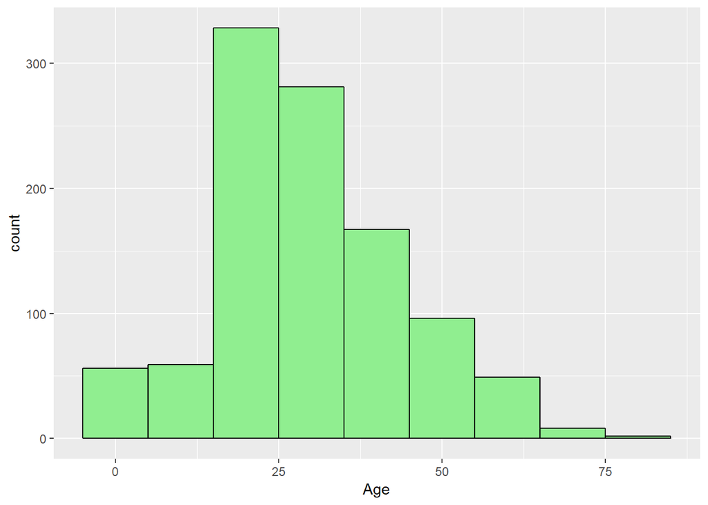

```r
g <- ggplot(data=ti_combined, aes(x=Age)) + geom_histogram(binwidth = 10, fill = "lightgreen", color = "Black")
g
```

Age distribution of whole dataset shows some kid + a lot of 20-40s, and less older people

## 2.1 Get Title Variable Out of Name Variable

```r
ti_combined$Title <- str_sub(ti_combined$Name,
                             str_locate(ti_combined$Name, ",")[ , 1] + 2,
                             str_locate(ti_combined$Name, "\\.")[ , 1] - 1)

table(ti_combined$Title)
```

```
##
##         Capt          Col          Don         Dona           Dr
##            1            4            1            1            8
##     Jonkheer         Lady        Major       Master         Miss
##            1            1            2           61          260
##         Mlle          Mme           Mr          Mrs           Ms
##            2            1          757          197            2
##          Rev          Sir the Countess
##            8            1            1
```

Most common titles are Mr, Mrs, Miss, and Master. The goal is to impute missing ages from title. It would be better to group rare titles to more common ones.

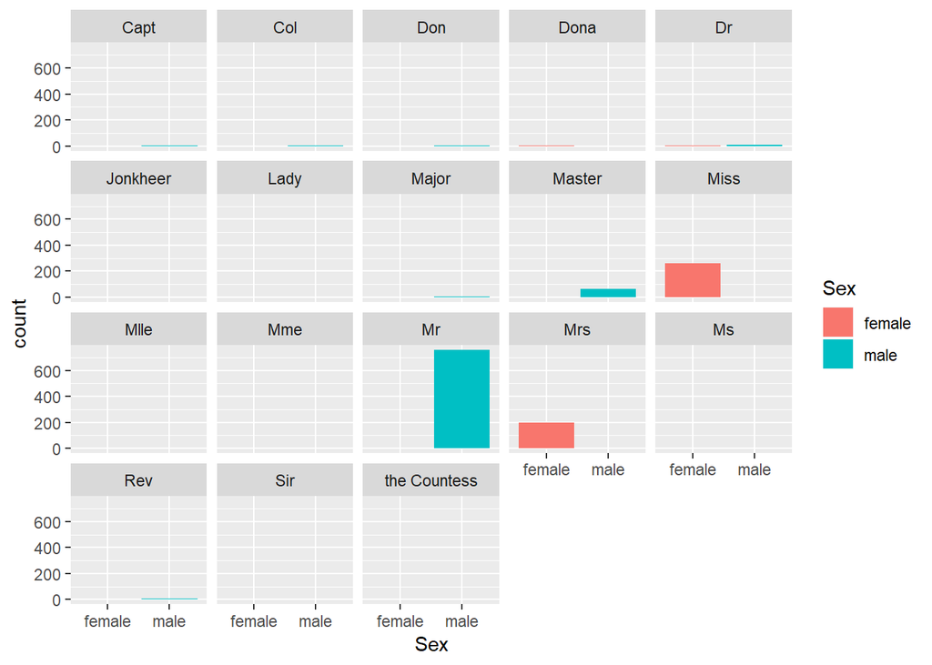

```r
g <- ggplot(data=ti_combined, aes(x=Sex,fill=Sex)) + geom_bar()+ facet_wrap(Title~.)
g
```

I Wanted to see gender distribution by each title but that didn’t work well!  
Filter for uncommon titles only to get better scale of graphs.

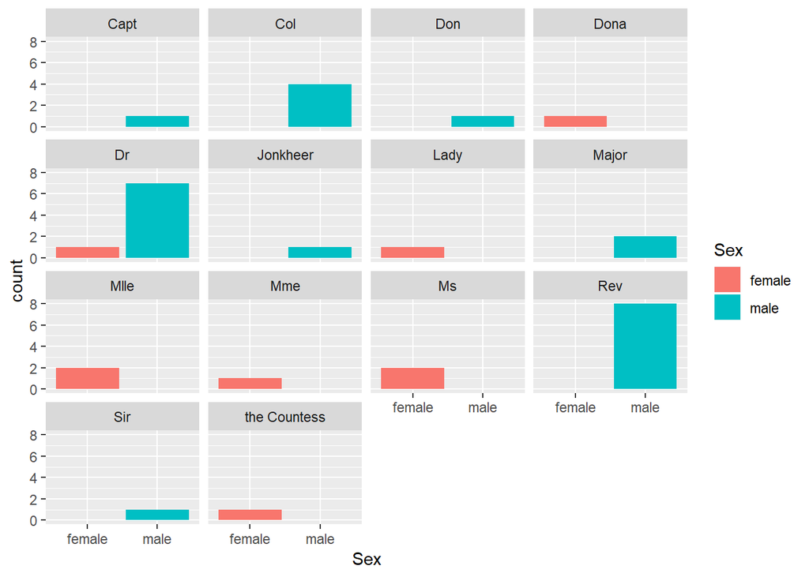

```r
ti_minor_title <- ti_combined[ti_combined$Title != 'Mr' &
                                ti_combined$Title != 'Mrs' &
                                ti_combined$Title != 'Miss' &
                                ti_combined$Title != 'Master',]

g <- ggplot(data=ti_minor_title, aes(x=Sex,fill=Sex)) + geom_bar()+ facet_wrap(Title~.)
g
```

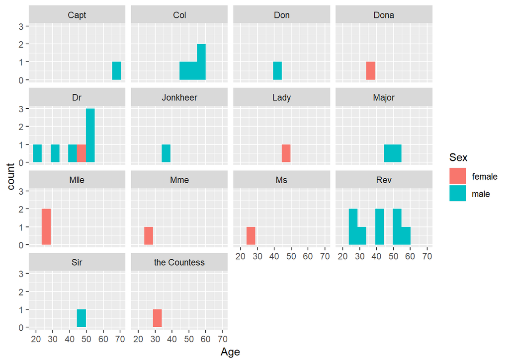

```r
g <- ggplot(data=ti_minor_title, aes(x=Age,fill=Sex)) + geom_histogram(bins = 10)+ facet_wrap(Title~.)
g
```

We these two plots. Now we have general idea of age/sex of person holding each title.  
Based on the distribution of Age,Sex and wikipedia info on old titles, I group them into major title categories.

## 2.2 Group Uncommon Titles into Common Titles

```r
Mr_title_list <- c("Capt", "Col", "Don", "Dr", "Jonkheer", "Major", "Rev", "Sir")
Mrs_title_list <- c("Dona", "Lady", "the Countess", "Mme")
Miss_title_list <- c("Ms", "Mlle")
Master_title_list <- c()

ti_combined[ti_combined$Title %in% Mr_title_list, "Title"] <- "Mr"
ti_combined[ti_combined$Title %in% Mrs_title_list, "Title"] <- "Mrs"
ti_combined[ti_combined$Title %in% Miss_title_list, "Title"] <- "Miss"
ti_combined[ti_combined$Title %in% Master_title_list, "Title"] <- "Master"

table(ti_combined$Title)
```

```
##
## Master   Miss     Mr    Mrs
##     61    264    783    201
```

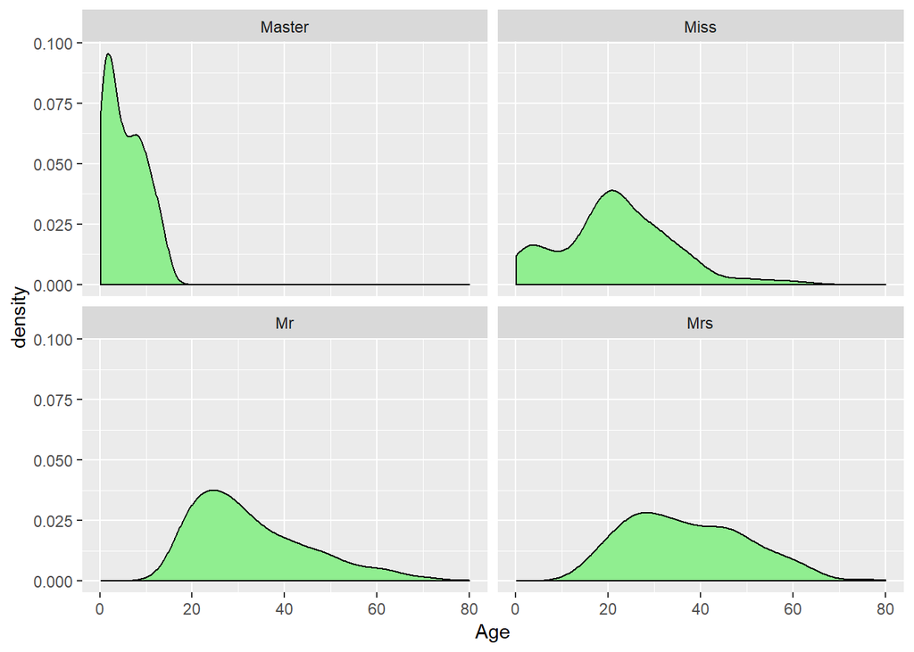

```r
g <- ggplot(data=ti_combined, aes(x=Age)) + geom_density(fill = "lightgreen") + facet_wrap(Title~.)
g
```

Looks good. Notice that all of them are right skewed to some degree. For the purpose of impute, I will use median age of each title over mean.

## 2.3 Use Median Age of Each Title for Missing Ages

```r
Mr_Median <- median(ti_combined[ti_combined$Title == "Mr", "Age"], na.rm = TRUE)
Mrs_Median <- median(ti_combined[ti_combined$Title == "Mrs", "Age"], na.rm = TRUE)
Miss_Median <- median(ti_combined[ti_combined$Title == "Miss", "Age"], na.rm = TRUE)
Master_Median <- median(ti_combined[ti_combined$Title == "Master", "Age"], na.rm = TRUE)

Median_By_Title <- data.frame("Title" = c("Mr", "Mrs", "Miss", "Master"),
                              "Median_Age" = c(Mr_Median,Mrs_Median,Miss_Median,Master_Median))
Median_By_Title
```

```
##    Title Median_Age
## 1     Mr       30.0
## 2    Mrs       35.5
## 3   Miss       22.0
## 4 Master        4.0
```

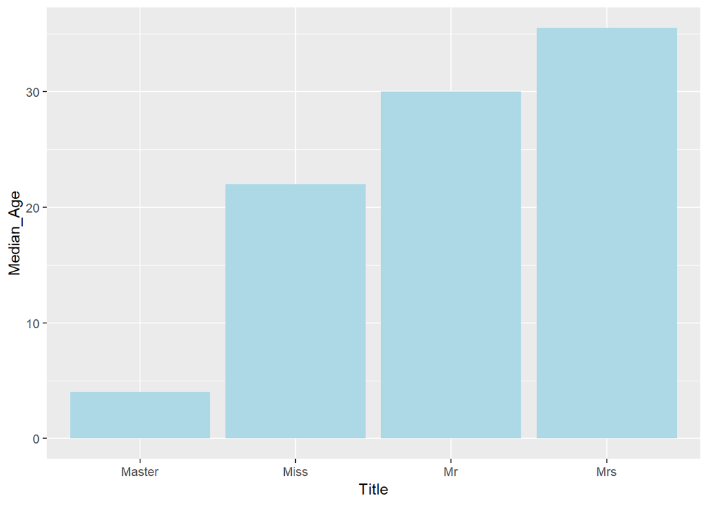

```r
g <- ggplot(data=Median_By_Title, aes(x=Title, y=Median_Age)) + geom_bar(stat = 'identity', fill = 'lightblue')
g
```

Median age for each title. These will be used if someone’s age is missing.

Now fill in NA Ages

```r
ti_combined[is.na(ti_combined$Age) & ti_combined$Title == "Mr", "Age"] <- Mr_Median
ti_combined[is.na(ti_combined$Age) & ti_combined$Title == "Mrs", "Age"] <- Mrs_Median
ti_combined[is.na(ti_combined$Age) & ti_combined$Title == "Miss", "Age"] <- Miss_Median
ti_combined[is.na(ti_combined$Age) & ti_combined$Title == "Master", "Age"] <- Master_Median

summary(ti_combined)
```

```
##   PassengerId      Survived          Pclass
##  Min.   :   1   Min.   :0.0000   Min.   :1.000
##  1st Qu.: 328   1st Qu.:0.0000   1st Qu.:2.000
##  Median : 655   Median :0.0000   Median :3.000
##  Mean   : 655   Mean   :0.3838   Mean   :2.295
##  3rd Qu.: 982   3rd Qu.:1.0000   3rd Qu.:3.000
##  Max.   :1309   Max.   :1.0000   Max.   :3.000
##                 NA's   :418
##                                Name          Sex           Age
##  Connolly, Miss. Kate            :   2   female:466   Min.   : 0.17
##  Kelly, Mr. James                :   2   male  :843   1st Qu.:22.00
##  Abbing, Mr. Anthony             :   1                Median :30.00
##  Abbott, Mr. Rossmore Edward     :   1                Mean   :29.55
##  Abbott, Mrs. Stanton (Rosa Hunt):   1                3rd Qu.:35.50
##  Abelson, Mr. Samuel             :   1                Max.   :80.00
##  (Other)                         :1301
##      SibSp            Parch            Ticket          Fare
##  Min.   :0.0000   Min.   :0.000   CA. 2343:  11   Min.   :  0.000
##  1st Qu.:0.0000   1st Qu.:0.000   1601    :   8   1st Qu.:  7.896
##  Median :0.0000   Median :0.000   CA 2144 :   8   Median : 14.454
##  Mean   :0.4989   Mean   :0.385   3101295 :   7   Mean   : 33.295
##  3rd Qu.:1.0000   3rd Qu.:0.000   347077  :   7   3rd Qu.: 31.275
##  Max.   :8.0000   Max.   :9.000   347082  :   7   Max.   :512.329
##                                   (Other) :1261   NA's   :1
##              Cabin      Embarked   IsTrainSet         Title
##  C23 C25 C27    :   6   C   :270   Mode :logical   Length:1309
##  B57 B59 B63 B66:   5   Q   :123   FALSE:418       Class :character
##  G6             :   5   S   :914   TRUE :891       Mode  :character
##  B96 B98        :   4   NA's:  2
##  C22 C26        :   4
##  (Other)        : 271
##  NA's           :1014
```

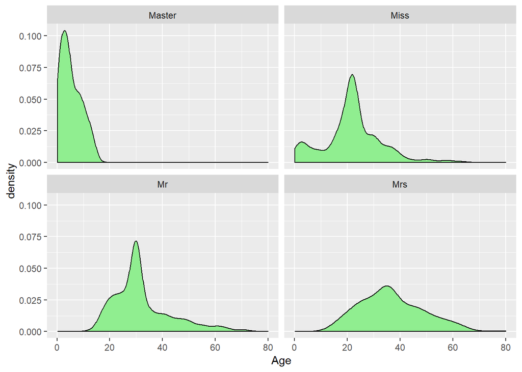

```r
g <- ggplot(data=ti_combined, aes(x=Age)) + geom_density(fill = "lightgreen") + facet_wrap(Title~.)
g
```

As expected, I can see peaks at median value. There could be better model to handle missing ages, but I will keep it simple for this project.

## 2.4 Handle other missing values and change data types

I will do very simple impute method for other missing values and also change data type to more appropriate ones. For Embarked, there are 2 NAs. I use mode value “S”

```r
ti_combined[is.na(ti_combined$Embarked),"Embarked"] <- "S"
```

One fare is missing. Use median for missing value.

```r
ti_combined[is.na(ti_combined$Fare),"Fare"] <- median(ti_combined$Fare, na.rm = TRUE)
```

```r
summary(ti_combined)
```

```
##   PassengerId      Survived          Pclass
##  Min.   :   1   Min.   :0.0000   Min.   :1.000
##  1st Qu.: 328   1st Qu.:0.0000   1st Qu.:2.000
##  Median : 655   Median :0.0000   Median :3.000
##  Mean   : 655   Mean   :0.3838   Mean   :2.295
##  3rd Qu.: 982   3rd Qu.:1.0000   3rd Qu.:3.000
##  Max.   :1309   Max.   :1.0000   Max.   :3.000
##                 NA's   :418
##                                Name          Sex           Age
##  Connolly, Miss. Kate            :   2   female:466   Min.   : 0.17
##  Kelly, Mr. James                :   2   male  :843   1st Qu.:22.00
##  Abbing, Mr. Anthony             :   1                Median :30.00
##  Abbott, Mr. Rossmore Edward     :   1                Mean   :29.55
##  Abbott, Mrs. Stanton (Rosa Hunt):   1                3rd Qu.:35.50
##  Abelson, Mr. Samuel             :   1                Max.   :80.00
##  (Other)                         :1301
##      SibSp            Parch            Ticket          Fare
##  Min.   :0.0000   Min.   :0.000   CA. 2343:  11   Min.   :  0.000
##  1st Qu.:0.0000   1st Qu.:0.000   1601    :   8   1st Qu.:  7.896
##  Median :0.0000   Median :0.000   CA 2144 :   8   Median : 14.454
##  Mean   :0.4989   Mean   :0.385   3101295 :   7   Mean   : 33.281
##  3rd Qu.:1.0000   3rd Qu.:0.000   347077  :   7   3rd Qu.: 31.275
##  Max.   :8.0000   Max.   :9.000   347082  :   7   Max.   :512.329
##                                   (Other) :1261
##              Cabin      Embarked IsTrainSet         Title
##  C23 C25 C27    :   6   C:270    Mode :logical   Length:1309
##  B57 B59 B63 B66:   5   Q:123    FALSE:418       Class :character
##  G6             :   5   S:916    TRUE :891       Mode  :character
##  B96 B98        :   4
##  C22 C26        :   4
##  (Other)        : 271
##  NA's           :1014
```

```r
str(ti_combined)
```

```
## 'data.frame':    1309 obs. of  14 variables:
##  $ PassengerId: int  1 2 3 4 5 6 7 8 9 10 ...
##  $ Survived   : int  0 1 1 1 0 0 0 0 1 1 ...
##  $ Pclass     : int  3 1 3 1 3 3 1 3 3 2 ...
##  $ Name       : Factor w/ 1307 levels "Abbing, Mr. Anthony",..: 109 191 358 277 16 559 520 629 417 581 ...
##  $ Sex        : Factor w/ 2 levels "female","male": 2 1 1 1 2 2 2 2 1 1 ...
##  $ Age        : num  22 38 26 35 35 30 54 2 27 14 ...
##  $ SibSp      : int  1 1 0 1 0 0 0 3 0 1 ...
##  $ Parch      : int  0 0 0 0 0 0 0 1 2 0 ...
##  $ Ticket     : Factor w/ 929 levels "110152","110413",..: 524 597 670 50 473 276 86 396 345 133 ...
##  $ Fare       : num  7.25 71.28 7.92 53.1 8.05 ...
##  $ Cabin      : Factor w/ 186 levels "A10","A14","A16",..: NA 82 NA 56 NA NA 130 NA NA NA ...
##  $ Embarked   : Factor w/ 3 levels "C","Q","S": 3 1 3 3 3 2 3 3 3 1 ...
##  $ IsTrainSet : logi  TRUE TRUE TRUE TRUE TRUE TRUE ...
##  $ Title      : chr  "Mr" "Mrs" "Miss" "Mrs" ...
```

Everything looks okay now except data types. Convert categorical variables to factors.

```r
ti_combined$PassengerId <- as.factor(ti_combined$PassengerId)
ti_combined$Survived <- as.factor(ti_combined$Survived)
ti_combined$Pclass <- as.factor(ti_combined$Pclass)
ti_combined$Title <- as.factor(ti_combined$Title)
```

We are done with cleaning data. Now split data to training and test set.

```r
ti_train2 <- ti_combined[ti_combined$IsTrainSet == TRUE,]
ti_test2 <- ti_combined[ti_combined$IsTrainSet == FALSE,]
```

# 3 Running Random Forest Model

I decided to leave out Title variable because it probably has a lot of interaction effect with sex and age.

```r
survived.equation <- "Survived ~ Pclass + Sex + Age + SibSp + Parch + Fare + Embarked"
survived.formula <- as.formula(survived.equation)

Titanic_RF <- randomForest(formula=survived.formula,
                           data = ti_train2,
                           ntree = 500,
                           mtry = 3,
                           nodesize = 0.01*nrow(ti_train2),
                           importance=TRUE)

Titanic_RF
```

```
##
## Call:
##  randomForest(formula = survived.formula, data = ti_train2, ntree = 500,      mtry = 3, nodesize = 0.01 * nrow(ti_train2), importance = TRUE)
##                Type of random forest: classification
##                      Number of trees: 500
## No. of variables tried at each split: 3
##
##         OOB estimate of  error rate: 15.82%
## Confusion matrix:
##     0   1 class.error
## 0 504  45  0.08196721
## 1  96 246  0.28070175
```

Error rate on the training set is 15.82%. Not bad for the first try!

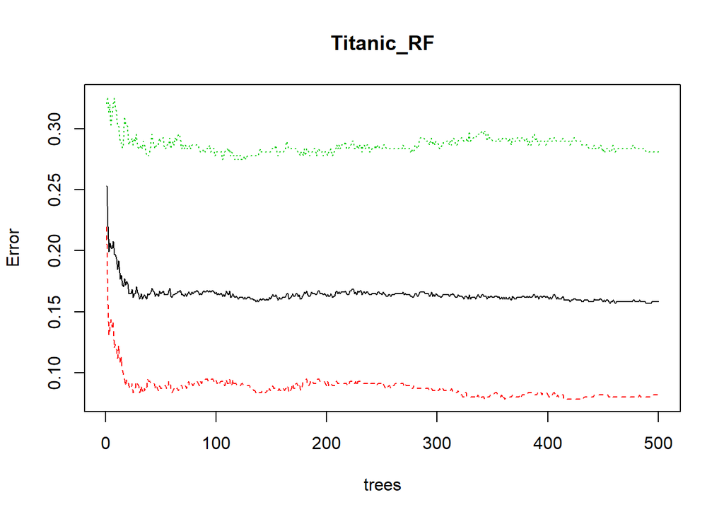

```r
plot(Titanic_RF)
```

It looks like there won’t be much gain by increasing number of trees. I will stick with the default.

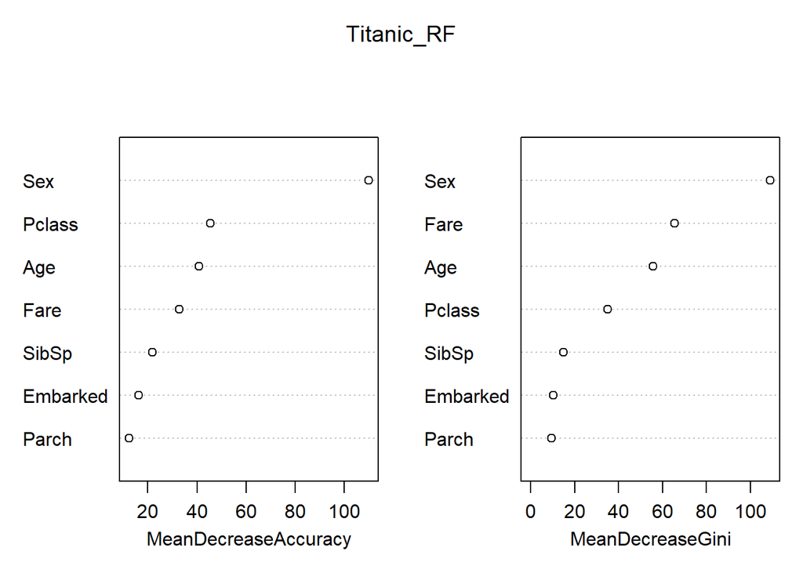

```r
varImpPlot(Titanic_RF)
```

As expected, sex and age are strong predictors. Fare and Pclass also have significance. If I were to use logistic regression or GLM for insurance pricing, I would start with these variables first.

# 4 Write Output File for Kaggle Submission

```r
Survived <- predict(Titanic_RF,newdata=ti_test2)

PassengerId <- ti_test2$PassengerId
output.df <- as.data.frame(PassengerId)
output.df$Survived <- Survived
write.csv(output.df,"titanic_kaggle_submission_kernel.csv",row.names = FALSE)
```

Thank you for reviewing my code!